# Session 1 — Clustered Data: ICC and the Design Effect

Why observations are not independent · intra-class correlation · design effect · effective sample size · Lab 1

Community Medicine Workshop

## Where we are

- Regression workshop: every row was an **independent** person
- Today: people live in **villages**, wards, clinics or schools, and are measured **repeatedly**
- By the end you can:
  - spot **clustered** and **repeated** data
  - compute and explain the **ICC**
  - compute the **design effect** and the **effective sample size**
  - say why a **naive** analysis gives standard errors that are too small

## Our data: a village blood-pressure trial

- **40 villages**, randomised 20 + 20 to a **hypertension programme** or usual care (synthetic data)
- **20 adults per village**, so **800 people**
- SBP measured at **0, 3, 6 and 12 months** (some visits missing)
- The **programme is given to a whole village**: the unit of randomisation is the village

```r
bp |> select(village, arm, person, age, months, sbp) |> head(6)
```

```
# A tibble: 6 × 6
  village arm       person    age months   sbp
  <fct>   <fct>     <fct>   <dbl>  <dbl> <dbl>
1 V01     Programme V01-P01    64      0   135
2 V01     Programme V01-P01    64      3   149
3 V01     Programme V01-P01    64      6   134
4 V01     Programme V01-P01    64     12   131
5 V01     Programme V01-P02    38      0   121
6 V01     Programme V01-P02    38      3   136
```

# Topic 1 — Levels and clusters

## Levels in the data

```r
bp |> summarise(villages = n_distinct(village), people = n_distinct(person), rows = n())
```

```
# A tibble: 1 × 3
  villages people  rows
     <int>  <int> <int>
1       40    800  2782
```

**Visit** (level 1) inside **person** (level 2) inside **village** (level 3). Rows that share a person or a village are **more alike** than rows that do not: they are **correlated**.

- **Clustered** data: people grouped in villages (one measurement each)
- **Repeated** (longitudinal) data: the same person measured several times
- Here we have **both**

## Why this matters

Most methods you know (linear and logistic regression, t-test, chi-square) assume **independent** observations. With correlated observations the **estimates** are often fine, but the **standard errors, CIs and p-values are wrong**, usually **too small**.

- Ten people from one village are not ten independent pieces of information
- The **effective** sample size is smaller than the number of rows
- The problem is largest for a **cluster-level** exposure, such as our programme

# Topic 2 — The ICC

## Villages differ

```r
b0 <- bp |> filter(months == 0)
b0 |> group_by(village, arm) |> summarise(mean_sbp = mean(sbp), .groups = "drop") |> arrange(mean_sbp) |> mutate(village = fct_inorder(village)) |>
  ggplot(aes(mean_sbp, village, colour = arm)) + geom_point(size = 2.5) + geom_vline(xintercept = mean(b0$sbp), linetype = 2) +
  scale_colour_manual(values = c(col_blue, col_red)) + labs(x = "Mean baseline SBP (mmHg)", y = "Village", colour = NULL) + theme(axis.text.y = element_blank())
```

At **baseline**, before any programme, village means range from about **120 to 141 mmHg**. With 20 random people per village we would expect much less spread.

## Villages differ

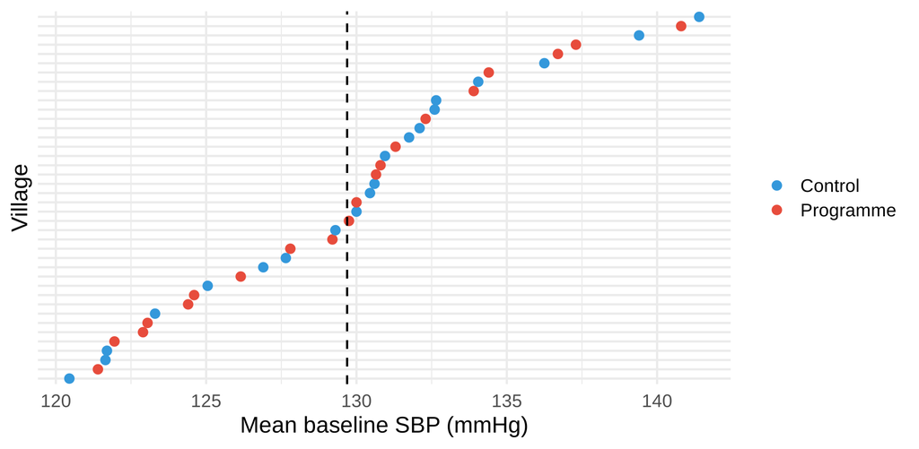

## The intra-class correlation

ICC = σ²~between villages~ / (σ²~between villages~ + σ²~within villages~)

- The **share of the total variance** that lies **between** clusters
- Also the **correlation** between two people from the same village
- **0**: clusters do not matter. **1**: everyone in a cluster is identical
- In community health ICCs are often small (**0.01 to 0.1**), but they still matter when clusters are large

## Estimating the ICC

```r
m0 <- lmer(sbp ~ 1 + (1 | village), data = b0)
VarCorr(m0)
```

```
 Groups   Name        Std.Dev.
 village  (Intercept)  4.317
 Residual             15.299
```

```r
icc(m0)
```

```
# Intraclass Correlation Coefficient

    Adjusted ICC: 0.074
  Unadjusted ICC: 0.074
```

ICC **= 0.074**: about **7%** of the variation in baseline SBP is **between villages**. It looks small. The next slide shows why it is not.

# Topic 3 — The design effect

## Design effect and effective sample size

DEFF = 1 + (m − 1) × ICC n<sub>eff</sub> = n / DEFF

```r
deff <- 1 + (20 - 1) * 0.074
c(design_effect = deff, effective_n = 800 / deff)
```

```
design_effect   effective_n
       2.4060      332.5021
```

- m = **cluster size** (20 per village)
- DEFF **2.4**: the variance is 2.4 times what a simple random sample would give
- The 800 people carry the information of only about **330 independent** people
- A **small ICC** with **large clusters** still gives a **large** design effect

## The naive analysis at 12 months

```r
fit_naive <- lm(sbp ~ arm, data = bp12)
summary(fit_naive)$coefficients["armProgramme", ]
```

```
     Estimate    Std. Error       t value      Pr(>|t|)
-4.0147535818  1.1750745643 -3.4165947455  0.0006733127
```

The estimate (about **−4.0 mmHg**) is fine, but its **SE (1.2)** treats 657 people as independent. The honest SE is about **1.4 times larger**.

## One valid simple analysis

```r
vm12 <- bp12 |> group_by(village, arm) |> summarise(mean_sbp = mean(sbp), .groups = "drop")
t.test(mean_sbp ~ arm, data = vm12)
```

```
    Welch Two Sample t-test

data:  mean_sbp by arm
t = 2.6681, df = 37.93, p-value = 0.01116
alternative hypothesis: true difference in means between group Control and group Programme is not equal to 0
95 percent confidence interval:
 1.032151 7.525524
sample estimates:
  mean in group Control mean in group Programme
               128.5770                124.2981
```

- Reduce each village to **one mean**: 40 independent numbers
- The **difference is about 4.3 mmHg** with a CI of **1.0 to 7.5**: the programme works, with an honest p-value
- Limits: covariate adjustment is harder, and villages of unequal size are weighted equally
- The next sessions give **model-based** alternatives

## 🔧 Switch to R — Lab 1

**File:** `clustered-workshop/labs/lab1_clusters.R`

- count villages, people and rows
- village means, the **ICC** and the **design effect**
- the naive analysis vs the village-level t-test

**Time:** 35 minutes · answer the Q questions in the comments

## Self-check quiz (1/5)

In this trial the programme is given to whole villages. Which statement about the 800 adults is correct?

- Adults in the same village are independent, because each was measured on their own
- The village is just a label for location and has no bearing on how the adults are analysed
- Adults in a village tend to resemble each other more than adults elsewhere
- Villages with many adults should be dropped so that all villages carry equal weight

## Self-check quiz (2/5)

A mixed model of baseline SBP gives an ICC of 0.07. What does it say?

- Seven percent of the adults in the villages have a raised blood pressure
- Two villages differ in their mean SBP by about 7 mmHg on average
- The programme is expected to lower SBP by 7% in each treated village
- About 7% of the variation in SBP lies between villages

## Self-check quiz (3/5)

Why can an ICC of only 0.07 still matter a great deal?

- The design effect grows with cluster size: with 20 per village it is more than 2
- A small ICC means the villages are nearly identical, so the programme effect gets hidden
- Statistical software rounds a small ICC up to 1 when it computes the standard errors
- The ICC becomes relevant just when the study has fewer than about ten villages

## Self-check quiz (4/5)

A design effect of 2.4 with 800 people gives an effective sample size of about…

- 1,900 people
- 330 people
- 800 people
- 40 people

## Self-check quiz (5/5)

Which analysis of the cluster-randomised programme effect is valid and simple?

- A t-test comparing the 800 individual values between the arms
- A chi-square test of the arm against the village number
- A linear model that ignores the village but adds age and sex
- A t-test comparing the 40 village means between the two arms

## Score and take-home

**Your score:**

- Data are **clustered** (people in villages) and/or **repeated** (visits in a person)
- **ICC** = share of variance between clusters
- **DEFF** = 1 + (m − 1) × ICC; **effective n** = n / DEFF
- A naive analysis keeps the estimate but gives **SEs that are too small**
- Simple valid fix: analyse **cluster means**

**Next:** Session 2: cluster-robust standard errors and GEE